# Face Analysis Technology Evaluation (FATE) Age Estimation & Verification

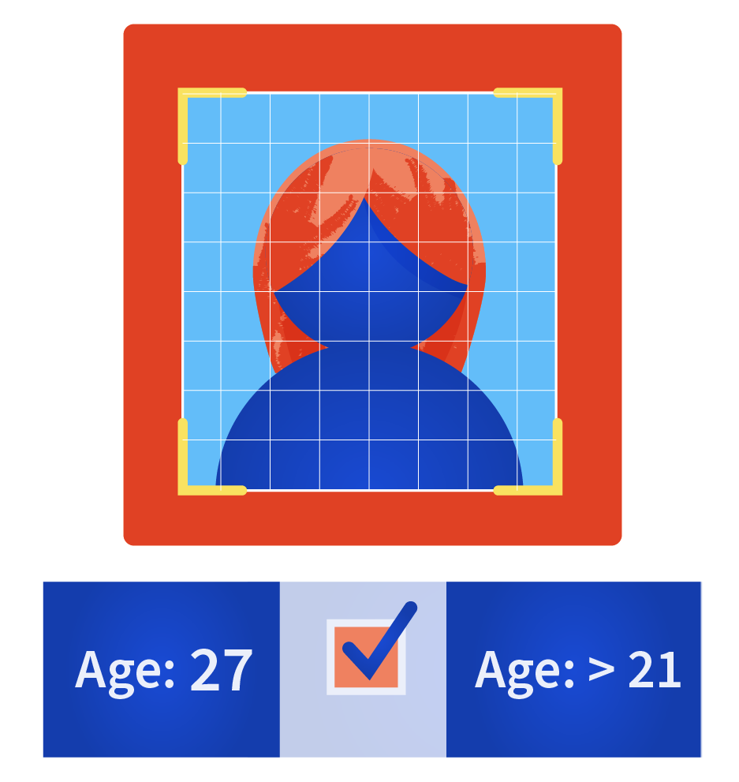

Credit: Natasha Hanacek/NIST

[Test Plan and API](https://pages.nist.gov/frvt/api/FATE_AgeEstimation_API_v2.pdf) | [Latest Report](https://pages.nist.gov/frvt/reports/aev/fate_aev_report.pdf) | [Participation Agreement](https://pages.nist.gov/frvt/agreements/frvt_participation_agreement.pdf) | [Validation](https://github.com/usnistgov/frvt) | [Encryption](https://www.nist.gov/itl/iad/image-group/products-and-services/encrypting-softwaredata-transmission-nist) | [Submit](https://pages.nist.gov/frvt/html/frvt_submission_form.html)

The FATE AEV track is open. Developers should submit no more frequently than every four months, using the [FATE Submission Form](https://pages.nist.gov/frvt/html/frvt_submission_form.html).

**[NOTE:]** The duration values for algorithms submitted since 2025-09-04 are provisional. From that date NIST ran all algorithms on a more recent Linux operating system (OS). The durations may be revised after the conclusion of our investigation into why numeric software is slower on identical hardware equipped with the new OS.

**[2025-04-11]** Version 2.0 of the [evaluation API](https://pages.nist.gov/frvt/api/FATE_AgeEstimation_API_v2.pdf)  
**[2024-05-28]** [NIST Interagency Report 8525](https://pages.nist.gov/frvt/reports/aev/fate_aev_report_IR8525.pdf).  
**[2014-03-31]** [NIST Interagency Report 7995](https://doi.org/10.6028/NIST.IR.7995).

Facial age verification has recently been mandated in legislation in a number of jurisdictions. These laws are typically intended to protect minors from various harms by verifying that the individual is above a certain age, within an age range, and, less commonly below a certain age. Other use-cases seek only to determine actual age. While the mechanism for estimating age is usually not specified in legislation, software-based face analysis is an attractive approach when a photograph can be captured.  
FATE AEV is an ongoing evaluation of software algorithms that inspect photos of a face to produce an age estimate. The output is set of reports on the accuracy and computational efficiency of algorithms. AEV is open to a worldwide community of developers. This evaluation will remain open indefinitely as a facility for developers to submit their algorithms whenever they are ready, but no more frequently than four calendar months.

**Results:** [last updated: 2026-09-13]

### MAE By Dataset and Variability

**Mean Absolute Error (MAE) values are averages of 26 MAE estimates from two sexes and 13 ages (18 to 30).**

- Algorithm name
- Submission data
- MAE for frontal view, no-glasses, visa photos, born in Mexico.
- MAE for frontal view, no-glasses, office application photos.
- MAE for airport concourse border crossing photos featuring variable pose, illumination and eye glasses.
- MAE for good quality mugshot portraits collected with two diffuse light sources and a uniform background.

**Age Estimation Noise**

- Proportion of frontal video frames for age estimate was not produced
- Mean absolute deviation of frontal age estimates about their mean - see section 2.7 in the [report](https://pages.nist.gov/frvt/reports/aev/fate_aev_report.pdf)
- Proportion of left-right yaw video frames for which age estimate was not produced
- Modelled increase in age estimation error for 90 degrees of head rotation - see section 2.8 in the [report](https://pages.nist.gov/frvt/reports/aev/fate_aev_report.pdf)

[interactive table not shown]

### MAE Across Geography

The table shows mean absolute error (MAE) for men and women born in six regions of the world. See the [AEV report](https://pages.nist.gov/frvt/reports/aev/fate_aev_report.pdf) for discussion of how these regions were selected and grouped. Lower values of MAE indicate better accuracy. Low variation across columns indicates equitable accuracy across countries of birth. MAE is estimated over high quality visa-like immigration office application photos. The uncertainty estimates span 95% of bootstrap estimates of the mean. The table is ordered by the mean of the 12 MAE ranks, but can be sorted on any column by clicking the small arrows in its header. The columns MAX-MIN and GINI summarize demographic variability into a single value; smaller values are better. The green shading indicates MAE below 2 years; yellow, pink, and red colors indicate MAE values above 3.5, 4.25 and 5 years.

[interactive table not shown]

### MAE By Interocular Distance

The results in the table below are based on measuring image resolution using the interocular distance (IOD) instead of image width. The values are mean absolute errors (MAE) with uncertainty estimates covering 95% of bootstrap estimates of the mean. The photographs are mugshot photographs of white males in the 18-30 age group collected at different venues across the United States using a standard photographic set up but with different cameras, client-side software, and different indviduals. The table shows MAE for six ranges of IOD measured in pixels. Most algorithms exhibit somewhat lower MAE in images with greater interocular distances. [AEV report](https://pages.nist.gov/frvt/reports/aev/fate_aev_report.pdf) has additional dataset detail. The table can be sorted on any column by clicking the small arrows in its header.

**Mean Absolute Error (MAE) by 6 ranges of IOD for white males aged 18 to 30.**

- [Dataset: Mugshot (high resolution)]
- Age 18-30 *Mean Absolute Error (MAE)* values are average of thirteen MAE values for age group 18, 19, 20, 21, 22, 23, 24, 25, 26, 27, 28, 29, and 30.

[interactive table not shown]

### Age Verification

Some developers implement an age verification function that takes a photo and legal age threshold (e.g. 18) and returns a confidence that the person in the photo is above that age. Age verification accuracy is defined over two populations, those underage and those overage. There is a tradeoff between two error rates: The proportion of the underage subjects assigned a high confidence of being overage, and the proportion of overage who are erroneously assigned a low confidence. These depend on a confidence threshold value, which can be adjusted by system owners.

The table shows verification accuracy for a legal age of 18. Each algorithm is configured with a confidence threshold that allows 10% of males aged 14 to 17 to be incorrectly classified as being over 18. This means the table lists their false positive rate (FPR) as approximately 0.1. The prior column shows FPR for females 14-17 at that threshold. The next two columns give false negative rates (FNR), the fraction of women and men aged 18 to 30 who are incorrectly classified as not being above 18.

| Algorithm | Date | FPR_FEMALE | FPR_MALE | FNR_FEMALE | FNR_MALE | FPR_invis_FEMALE | FPR_invis_MALE | FNR_invis_FEMALE | FNR_invis_MALE | Score Threshold |
| --- | --- | --- | --- | --- | --- | --- | --- | --- | --- | --- |
| ayonix-001 | 2026-07-23 | 0.180 | 0.097 | 0.385(18) | 0.393(19) | 0.1803349448851878 | 0.09712676612405516 | 0.3850311576741221 | 0.3928083477608693 | 0.843 |
| bynn-000 | 2026-06-17 | 0.089 | 0.099 | 0.475(19) | 0.282(17) | 0.08857565402972112 | 0.09851274254611544 | 0.4746362003481034 | 0.2817740625414977 | 0.316 |
| cognitec-000 | 2025-07-11 | 0.137 | 0.100 | 0.244(12) | 0.169(13) | 0.1373253605359372 | 0.09956203221785884 | 0.2444397915673172 | 0.1687699837481277 | 0.656 |
| cognitec-001 | 2026-04-30 | 0.127 | 0.096 | 0.251(13) | 0.149(8) | 0.1268408306956176 | 0.09625718207918998 | 0.250692983409004 | 0.14915877361545 | 0.904 |
| cvut-003 | 2025-05-06 | 0.111 | 0.098 | 0.323(15) | 0.161(11) | 0.111455258038011 | 0.097812309670229 | 0.3229193215554151 | 0.1614495637131286 | 0.924 |
| cyberlink-001 | 2025-07-30 | 0.166 | 0.099 | 0.261(14) | 0.190(15) | 0.1664191120542534 | 0.0987018491443796 | 0.2613092070645698 | 0.1896983679980362 | 0.862 |
| dermalog-003 | 2026-05-13 | 0.191 | 0.097 | 0.206(11) | 0.144(7) | 0.1909420276405227 | 0.09746844427893778 | 0.2064569700228741 | 0.1441023542360691 | 0.868 |
| facehawk-001 | 2026-06-15 | 0.141 | 0.100 | 0.752(21) | 0.726(21) | 0.1405446524938227 | 0.0998442279670018 | 0.7522385017406685 | 0.7263630864462772 | 28.5 |
| idemia-002 | 2025-06-23 | 0.104 | 0.099 | 0.675(20) | 0.651(20) | 0.1039309685442108 | 0.09919555996193946 | 0.6752257414146823 | 0.6506916364852566 | 1.051 |
| incode-002 | 2026-08-03 | 0.250 | 0.097 | 0.132(4) | 0.132(4) | 0.2503799288392931 | 0.0969319944548204 | 0.1322222211163554 | 0.1315301009510345 | 0.778 |

[output cut: 11 more lines]

[interactive chart not shown]

### Challenge-25 & Child Online Safety (13-16)

The table shows accuracy measures for 2 common applications, Challenge-25 age-restriction and children age 13-16 online chatroom access. False positive rates quantify how often people outside the allowed age range are estimated to be within required category. True positive rates quantify how often children within age 13-16 are estimated to be within that age range.

**Challenge 25:**

- [Dataset: Application (good quality), Border (medium quality)]
- Application - *False Positive Rate (FPR)* values are averages of 12 FPR estimates from two sexes and six regions-of-birth for subjects aged 17.
- Border - *False Positive Rate (FPR)* values are averages of 12 FPR estimates from two sexes and six regions-of-birth for subjects aged 17.

**Child Online Safety (13-16):**

- [Dataset: Visa (good quality)]
- Age 13-16 - *Mean Absolute Errors (MAE)* are averages of four MAE values for age group 13, 14, 15, and 16 (below 17).
- Age 13-16 - *True Positive Rates (TPR)* are proportions of subjects aged 13 to 16 whose age is correctly estimated as 13 to 16 (below 17).
- Age 13-16 - *False Negative Rates (FNR↓)* are proportions of subjects aged 13 to 16 whose age is incorrectly estimated as 8 to 12.
- Age 13-16 - *False Negative Rates (FNR↑)* are proportions of subjects aged 13 to 16 whose age is incorrectly estimated as 17 to 22.
- Age 8-12 - *False Positive Rates (FPR)* are proportions of subjects aged 8 to 12 but whose age is incorrectly estimated as 13 to 16 (below 17).
- Age 17-22 - *False Positive Rates (FPR)* are proportions of subjects aged 17 to 22 but whose age is incorrectly estimated as 13 to 16 (below 17).

[interactive table not shown]

### Resource Cost

**Resource Usage:**

- AE Time (msec) is the median duration of the AE function call.
- Config (MB) is the total size of the neural network model and configuration data of the algorithm.
- Lib (MB) is the total size of the implemenation’s compiled libraries.

[interactive table not shown]

To participate in this evaluation, developers need to submit a participation agreement to NIST, wrap their software behind the published C++ API, run their libraries through the provided validation package (which creates a submission package), encrypt the package, and provide a download link for the encrypted submission package.

**[Participation agreement]** [FATE](https://www.nist.gov/programs-projects/face-recognition-vendor-test-frvt-ongoing) is conducted by NIST, an agency of the United States Government. Participation is free of charge. [FATE](https://www.nist.gov/programs-projects/face-recognition-vendor-test-frvt-ongoing) is open to a global audience of face recognition developers. All organizations who seek to participate in FATE must sign all pages of this [Participation Agreement](https://pages.nist.gov/frvt/agreements/frvt_participation_agreement.pdf) and submit it with their algorithm submission using the [Submission Form](https://pages.nist.gov/frvt/html/frvt_submission_form.html). [last update: 2023-08-17]

**[API]** General and common information shared between all tracks of the FRTE/FATE evaluations are documented in a [General Evaluation Specifications](https://pages.nist.gov/frvt/api/FRVT_common.pdf), which includes hardware and operating system environment, software requirements, reporting, and common data structures that support the APIs. [last update: 2023-08-17]

**[Validation]** A [validation package](https://github.com/usnistgov/frvt) has been published. All participants must run their software through the validation package prior to submission. The purpose of validation is to ensure consistent algorithm output between your execution and NIST’s execution. [last update: 2023-08-17]

**[Encryption]** All submissions must be properly encrypted and signed before transmission to NIST. This must be done according to these [instructions](https://www.nist.gov/system/files/documents/2021/10/25/nist_encryption.pdf) using the FATE Ongoing public key linked from this [page](https://www.nist.gov/itl/iad/image-group/products-and-services/encrypting-softwaredata-transmission-nist). Participants must email their public key to NIST. The participant’s public key must correspond to the participant’s public-key fingerprint provided on the signed Participation Application. [last update: 2022-07-03]

**[Submission]** All algorithm submissions must be submitted through the [Submission Form](https://pages.nist.gov/frvt/html/frvt_submission_form.html), which requires encrypted files be provided as a download link from a generic http server (e.g., Google Drive). We cannot accept Dropbox links. NIST will not register, or establish any kind of membership, on the provided website. Participants can submit their algorithm(s), participation agreement, and GPG key at the same time via the submission form. [last update: 2023-07-03]

Participants must subscribe to the evaluation mailing list to receive emails when new reports are published or announcements are made.

Inquiries and comments may be submitted to frvt@nist.gov. Subscribe to the evaluation mailing list to receive emails when announcements or updates are made.

## Related NIST Projects

##### [Ongoing Face Evaluations](https://www.nist.gov/programs-projects/face-recognition-vendor-test-frvt-ongoing)

## FRTE Projects

##### [FRTE 1:1 Verification](https://pages.nist.gov/frvt/html/frvt11.html)

##### [FRTE 1:N Identification](https://pages.nist.gov/frvt/html/frvt1N.html)

##### [FRTE Demographic Effects](https://pages.nist.gov/frvt/html/frvt_demographics.html)

##### [FRTE Face Mask Effects](https://pages.nist.gov/frvt/html/frvt_facemask.html)

##### [FRTE Paperless Travel](https://pages.nist.gov/frvt/html/frvt_paperless_travel.html)

##### [FRTE Twins Demonstration](https://pages.nist.gov/frvt/html/frvt_twins_demonstration.html)

##### [FRTE FIVE](https://pages.nist.gov/frvt/html/frte_five.html)

## FATE Projects

##### [FATE MORPH](https://pages.nist.gov/frvt/html/frvt_morph.html)

##### [FATE Quality](https://pages.nist.gov/frvt/html/frvt_quality.html)

##### [FATE PAD](https://pages.nist.gov/frvt/html/frvt_pad.html)

##### [FATE Age Estimation & Verification](https://pages.nist.gov/frvt/html/frvt_age_estimation.html)